# Notebook

How to compare two functions?

Cosine Similarity; DFT; FFT; STFT;

📋 Table of Contents

Point-wise comparison

Distance measure

Similarity measure

Fourier Transform

Dirac Delta function

Implement Discrete Fourier Transform

Implement Fast Fourier Transform

Implement Short-time Fourier Transform

References:

1. [The Analytical Theory of Heat (Translation), Joseph Fourier; 1878](https://archive.org/details/analyticaltheory00fourrich/page/n15/mode/2up)
2. The Fourier Integral and Certain of its Applications, Norbert Weiner; 1933

Although we start with continuous functions but our focus will mainly be on dicrete functions due to the ease of performing experiments on them with code.

## Point-wise comparison

If $f(x), g(x) \in \mathbb{R}$ and $x \in \mathbb{R}$ then $f(x)$ and $g(x)$ are identical if  
$f(x) = g(x) \forall x \in \mathbb{R} $

For discrete functions,  
$f[n] = g[n]$ for $n \in \set{0, 1, 2, 3, ...}$

## Distance measure

If $x, y \in \mathbb{R}^n$ be digital signals with zero indexing then the Euclidean distance is given by

If $x, y$ are similar, we should get lower Euclidean distance.

```python
def get_euc_dist(f1, f2):
    """
    Compute Euclidean distance between f1 and f2.

    Paramters
    ---------
    f1: ndarray
        Function 1
    f2: ndarray
        Function 2, same size as f1

    Returns
    -------
    float
        Euclidean distance.
    """

    return np.sum(np.sqrt((f1 - f2)**2))

print(f"Euclidean distance between y and y1: {get_euc_dist(y, y1):.4f}")
print(f"Euclidean distance between y and y2: {get_euc_dist(y, y2):.4f}")
```

```
Euclidean distance between y and y1: 59.3881
Euclidean distance between y and y2: 11.0864
```

## Similarity measure

If $x, y \in \mathbb{R}^n$ be digital signals with zero indexing then the dot product between is given by

$s_{x, y} = \sum_{n=0}^{N-1} x_n y_n$

If the polarity of $x_n, y_n$ is same then the summand becomes +ve (similarity) else -ve (dissimilarity).

If the polarity of $x_n, y_n$ is 0 then the summand becomes 0 and we end up getting no contributions from those points.

If $x, y$ are similar, we should get high dot product.

```python
print(f"Dot product between y and y1: {np.dot(y, y1):.4f}")
print(f"Dot product between y and y2: {np.dot(y, y2):.4f}")
```

```
Dot product between y and y1: -7.1828
Dot product between y and y2: 32.9727
```

## Similarity measure

If I ask you to compute how similar two functions $f_1(t)$ and $f_2(t)$ are, how would you do it?

Let's take an example, below are two signals $y_1(t)$ and $y_2(t)$. Which one of the following is more similar to $y(t)$.

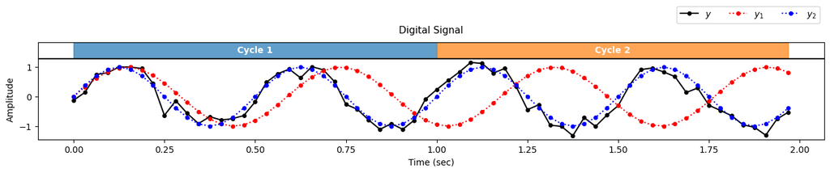

## Fourier Transform

**Fourier Transform** that we know of today was ideated in the **19th** century when **Joseph Fourier** was working on **heat conduction** problem. His work was published in French in **1822**. [1] is english translation of his work that was published in **1878**. Since then, there had been wide adoption of his ideas in different domains, [2] work by Norbert is what shaped the modern view of his ideas. To this date, Fourier transform forms the backbone of **Signal Analysis** domain.

## Definition

Given a function $f(t)$, it's Fourier transform is given by:

$F(x) = \int_{-\infty}^{\infty} f(t)e^{-j\omega t} dt$

## Sinusoid

To appreciate what Fourier transform does we need to understand sinusoid.  
A sinusoid is a function given by

$y = A\sin(\omega t + \phi)$

where,  
$\omega = 2\pi f$: Angular frequency (radians)  
$\phi$: Phase (radians)

$f$ is basically the number of cycles a sinusoid completes in 1 sec.

When $\phi=0$, we call it **pure sinusoid**.

### Sinusoids at different frequency

Frequency/angular frequency represents how faster a sinusoid is going to complete its full cycle. A sinusoid with $f = 1 hz$ or $\omega = 2\pi f$ implies that the sinusoid completes it cycle in $1 sec$.

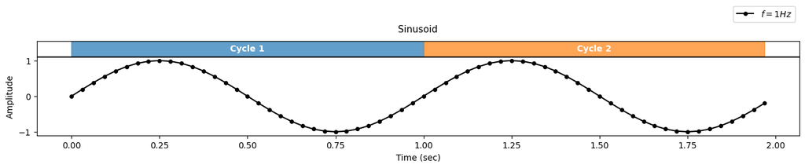

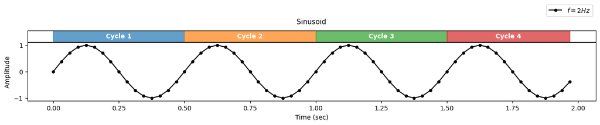

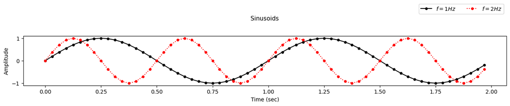

### Sinusoids with different phase

Think of phase as a metric that traslate the sinusoid along the time axis. Adding $+ve$ phase, sinusoids moves backward and adding $-ve$ phase moved the sinusoid forward.

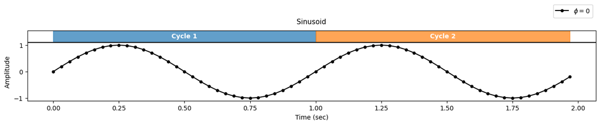

[figure not shown]

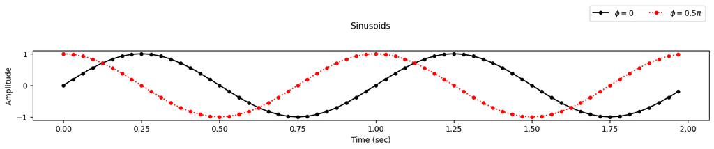

## Complex exponentials

The term $e^{-j\omega t}$ needs to be understood to build an intuitive understanding of Fourier's tranform.

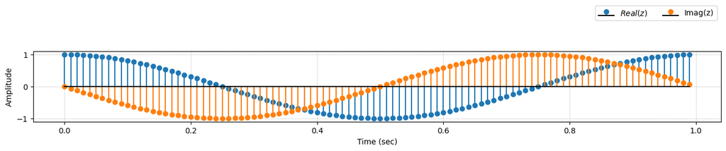

## Analysing a noisy simulated signal

We create probe which is nothing but a pure sinusoid at a given $f$ and $\phi$. Let's make some observation by plotting some probes next to the signal.

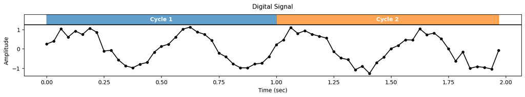

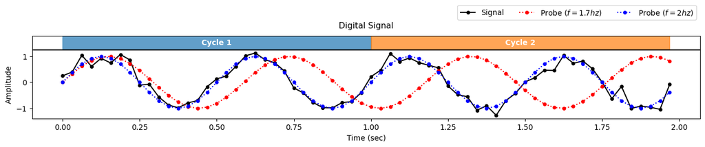

We create probe which is nothing but a pure sinusoid at a given $f$ and $\phi$. Let's make some observation by plotting some probes next to the signal.

## Discrete Fourier Transform

Any signal can be broken down into linear combination of sinusoids.

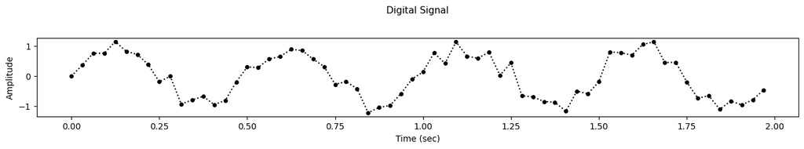